# Palmetto binary logistic regression

Larissa Neilson

2/5/2021

```r
# Read in the data and convert columns to numeric
palmetto <- read_csv(here("data", "palmetto.csv"),
                     col_types = cols(.default = "c")) %>%
  mutate(height = as.numeric(height)) %>%
  mutate(length = as.numeric(length)) %>%
  mutate(width = as.numeric(width)) %>%
  mutate(green_lvs = as.numeric(green_lvs)) %>%
  clean_names()
```

```r
# Create smaller subset to work with and convert species to a factor
palmetto_new <- palmetto %>%
  select(species, height, length, width, green_lvs) %>%
  mutate(species = as.factor(species))
```

### Exploratory visualization of the relationships between tree variables

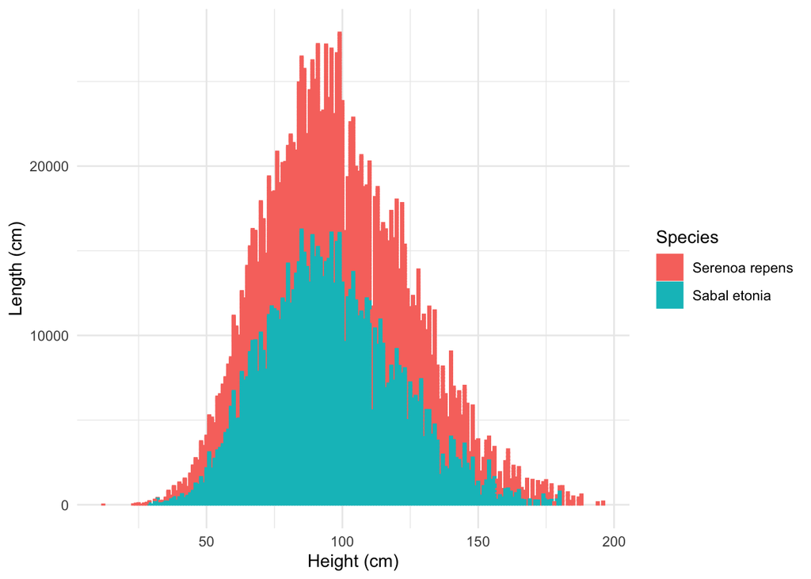

```r
# Visualize the data in three graphs comparing the variables to height
ggplot(data = palmetto_new, aes(x = height, y = length)) +
  geom_col(aes(color = species, fill = species)) +
  labs(x = "Height (cm)", y = "Length (cm)") +
  scale_color_discrete(name = "Species",
                       labels = c("Serenoa repens", "Sabal etonia")) +
  scale_fill_discrete(name = "Species",
                      labels = c("Serenoa repens", "Sabal etonia")) +
  theme_minimal()
```

**Figure 1.** Tree height vs. canopy length for both palmetto species.

- *Serenoa repens* has a greater canopy length than *Sabal etonia* overall. Canopy length generally increases with height, but starts to decrease as the trees get taller.

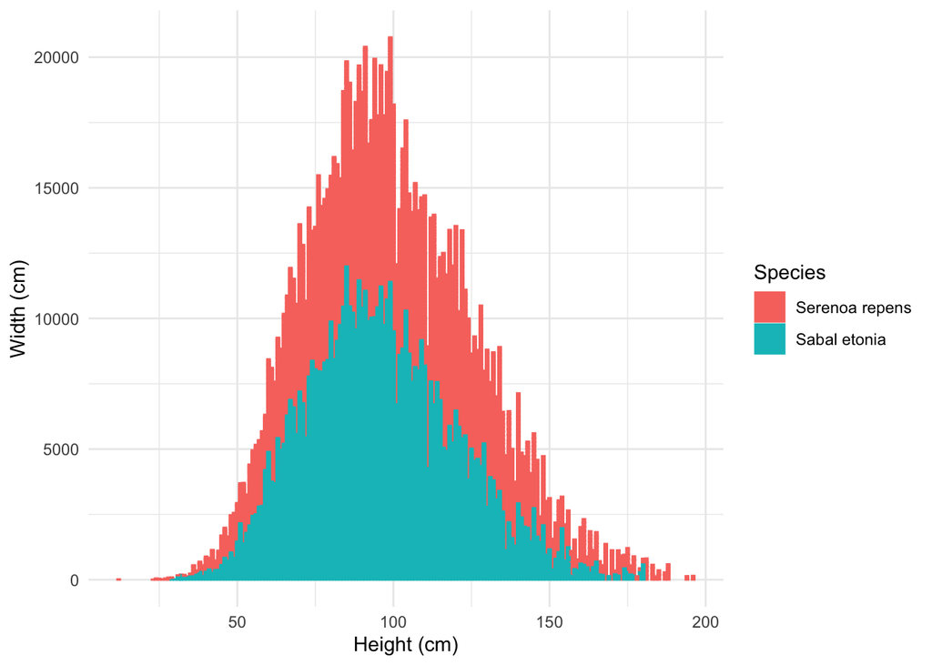

```r
ggplot(data = palmetto_new, aes(x = height, y = width)) +
  geom_col(aes(color = species, fill = species)) +
  labs(x = "Height (cm)", y = "Width (cm)") +
  scale_fill_discrete(name = "Species",
  labels = c("Serenoa repens", "Sabal etonia")) +
  scale_color_discrete(name = "Species",
                       labels = c("Serenoa repens", "Sabal etonia")) +
  scale_fill_discrete(name = "Species",
                      labels = c("Serenoa repens", "Sabal etonia")) +
  theme_minimal()
```

**Figure 2.** Tree height vs. canopy width for both palmetto species.

- *Serenoa repens* has a greater canopy width than *Sabal etonia* overall. Canopy width generally increases with height, but starts to decrease as the trees get taller.

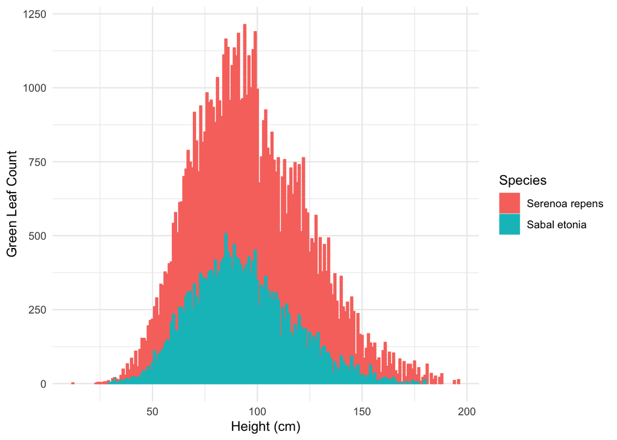

```r
ggplot(data = palmetto_new, aes(x = height, y = green_lvs)) +
  geom_col(aes(color = species, fill = species)) +
  labs(x = "Height (cm)", y = "Green Leaf Count") +
  scale_color_discrete(name = "Species",
                       labels = c("Serenoa repens", "Sabal etonia")) +
  scale_fill_discrete(name = "Species",
                      labels = c("Serenoa repens", "Sabal etonia")) +
  theme_minimal()
```

**Figure 3.** Tree height vs. green leaf count for both palmetto species.

- *Serenoa repens* has significantly more green leaves than *Sabal etonia*. Green leaf count generally increases with height, but starts to decrease as the trees get taller.

```r
# Palmetto binary logistic regression
palmetto_blr <- glm(species ~ height + length + width + green_lvs,
                            data = palmetto_new,
                            family = "binomial")
palmetto_blr

summary(palmetto_blr)

# 0 = Serenoa repens, 1 = Sabal etonia
```

### Binary logistic regression

**Table 1.** Binary logistic regression results. Plant height, canopy length, canopy width and green leaves are the predictor variables used to understand how they relate to probability of a palmetto being *Sabal etonia* or *Serenoa repens* (All p-values are < 2e^-16). Data: Abrahamson 2019

```r
# Make finalized table of blr results
palmetto_blr_tidy <- tidy(palmetto_blr)

palmetto_blr_tidy %>%
  kbl(col.names = c(" ",
                    "Estimate",
                    "Standard Error",
                    "Statistic",
                    "P-value")) %>%
  kable_styling("hover", full_width = F)
```

|  | Estimate | Standard Error | Statistic | P-value |
| --- | --- | --- | --- | --- |
| (Intercept) | 3.2266851 | 0.1420708 | 22.71180 | 0 |
| height | -0.0292173 | 0.0023061 | -12.66984 | 0 |
| length | 0.0458233 | 0.0018661 | 24.55600 | 0 |
| width | 0.0394434 | 0.0021000 | 18.78227 | 0 |
| green_lvs | -1.9084747 | 0.0388634 | -49.10728 | 0 |

### Model accuracy

**Table 2.** Counts of correctly and incorrectly classified palmetto species based on the binary logistic regression. This model was very accurate at predicting whether the species was *Sabal etonia* or *Serenoa repens* with a 92.62% and 90.77% success rate, respectively. Data: Abrahamson 2019

```r
# Find probabilities
palmetto_blr_fitted <- palmetto_blr %>%
  augment(type.predict = "response")

# Make finalized table showing # correctly & incorrectly classified, and % correct
palmetto_fitted_prob <- palmetto_blr_fitted %>%
  mutate(classification = case_when(species == 2 & .fitted >= .5 ~ "Correct",
                               species == 1 & .fitted >= .5 ~ "Incorrect",
                               species == 2 & .fitted <= .5 ~ "Incorrect",
                               species == 1 & .fitted <= .5 ~ "Correct")) %>%
  mutate(species = case_when(species == 1 ~ "Serenoa repens",
                             species == 2 ~ "Sabal etonia")) %>%
  select(species, .fitted, classification)

palmetto_final_tbl <- palmetto_fitted_prob %>%
  group_by(species, classification) %>%
  summarize(number_correct = n()) %>%
  pivot_wider(names_from = classification,
              values_from = number_correct) %>%
  mutate(percent_correct = case_when(species == "Sabal etonia" ~ (5701/(5701+454)*100),
                                     species == "Serenoa repens" ~ (5548/(5548+564)*100)))

palmetto_final_tbl %>%
  kbl(col.names = c("Species",
                    "# Correctly Classified",
                    "# Incorrectly Classified",
                    "% Correctly Classified")) %>%
  kable_styling("hover", full_width = F)
```

| Species | # Correctly Classified | # Incorrectly Classified | % Correctly Classified |
| --- | --- | --- | --- |
| Sabal etonia | 5701 | 454 | 92.62388 |
| Serenoa repens | 5548 | 564 | 90.77225 |

#### Data citation

Abrahamson, W.G. 2019. Survival, growth and biomass estimates of two dominant palmetto species of south-central Florida from 1981 - 2017, ongoing at 5-year intervals ver 1. Environmental Data Initiative. https://doi.org/10.6073/pasta/f2f96ec76fbbd4b9db431c79a770c4d5